# hw4_jerome_wong

Jerome Wong

12/5/2021

```r
knitr::opts_chunk$set(echo = TRUE)
library(igraph)
library(sand)
library(blockmodels)
data(lazega)
```

Using the blockmodels package, ﬁt an SBM without covariates.

```r
lazega_out <- BM_bernoulli("SBM", as_adj(lazega, sparse=FALSE), verbosity=3, plotting= "")
lazega_out$estimate()
```

[output not shown]

• Report how many groups you found, plot the graph with nodes colored by cluster (and use set.seed as in lab), and provide a table of the estimated edge probabilities.

```r
set.seed(42)
best_fit_membership_probs <- lazega_out$memberships[[which.max(lazega_out$ICL)]]$Z
clust_assignments <- apply(best_fit_membership_probs, 1, which.max)
hat_P_blockmodels = lazega_out$model_parameters[[which.max(lazega_out$ICL)]]$pi
hat_P_blockmodels
```

```
##            [,1]       [,2]      [,3]
## [1,] 0.44703951 0.01602947 0.1115080
## [2,] 0.01602947 0.01970998 0.1420525
## [3,] 0.11150800 0.14205249 0.6109218
```

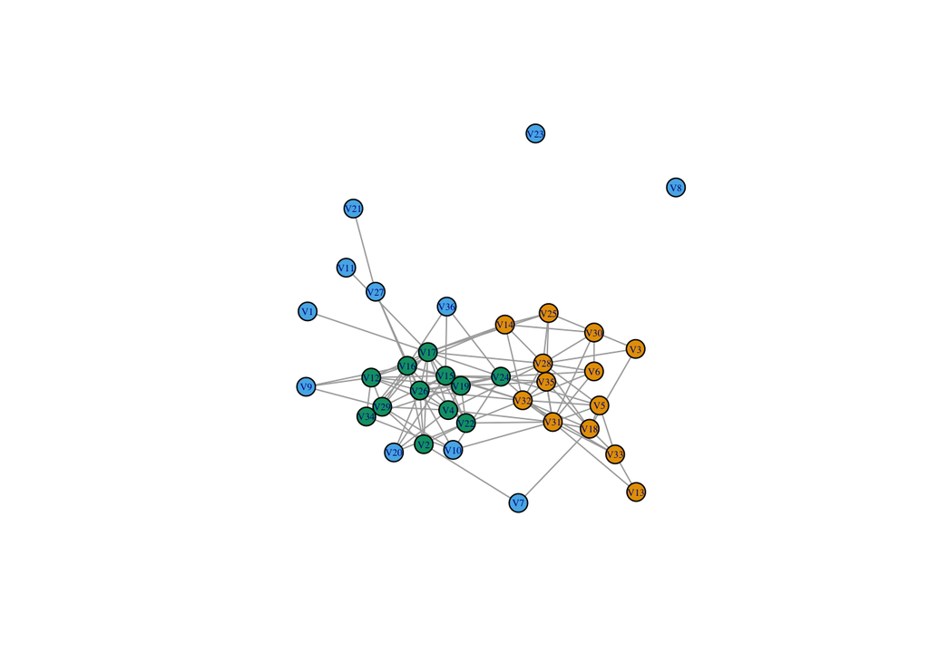

```r
plot(lazega, vertex.color=clust_assignments, vertex.size = 10, vertex.label.cex= 0.45)
```

• In just 2-3 sentences, summarize the table: do the groups have roughly equal intragroup edge probabilities, or if not, how would you summarize what you see? Which intergroup edge probabilities are the largest or smallest, or are they all comparable?

The intragroup edge probabilities are highest between group 3 and lowest between group 2. The highest intergroup edge probability is between group 2 and group 3.

• Look at the node degree and node attributes by cluster. Do you notice diﬀerences between the clusters the model found? How would you characterize the clusters, or what underlying structure do you think the clusters might be picking up in terms of degree and/or speciﬁc node attributes?

```r
degree(lazega)[clust_assignments=="1"]
```

```
##  V3  V5  V6 V13 V14 V18 V25 V28 V30 V31 V32 V33 V35
##   3   6   5   2   6   8   5  13   4  13  12   5   7
```

```r
degree(lazega)[clust_assignments=="2"]
```

```
##  V1  V7  V8  V9 V10 V11 V20 V21 V23 V27 V36
##   1   2   0   3   5   1   4   1   0   3   3
```

```r
degree(lazega)[clust_assignments=="3"]
```

```
##  V2  V4 V12 V15 V16 V17 V19 V22 V24 V26 V29 V34
##   6   9   9  11  13  15  10   9   9  12   9   6
```

Cluster 2 has the lowest degrees whereas Cluster 3 has the highest degrees. Cluster 3 could be seen as the hubs of network and is picking up the people that are most connected. As we also saw in the previous question, it has the highest intergroup edge probability with cluster 2 as well.

Now ﬁt the same model except include a single covariate: a matching eﬀect on one of the covariates, as in lab. For example, you might choose the indicator function for whether two lawyers practice the same type of law, in which case your model is

$$\text{logit}\left(P(Y_{ij} \:|\: c_i, c_j, \text{Practice}_i, \text{Practice}_j)\right) = m_{c_i, c_j} + \beta\: \text{I}\{\text{Practice}_i = \text{Practice}_j\}$$

```r
n = vcount(lazega)
practice = matrix(NA, nrow=n, ncol=n)
for(i in 1:n){
  for(j in 1:n){
    practice[i, j] = (V(lazega)$Practice[i]==V(lazega)$Practice[j])
  }
}
lazega_out <- BM_bernoulli_covariates("SBM", as_adj(lazega, sparse=FALSE), practice, verbosity=3, plotting="")
lazega_out$estimate()
```

[output not shown]

• Report how many groups you found, plot the graph with nodes colored by cluster (and use set.seed as in lab), and provide a table of the estimated edge probabilities.

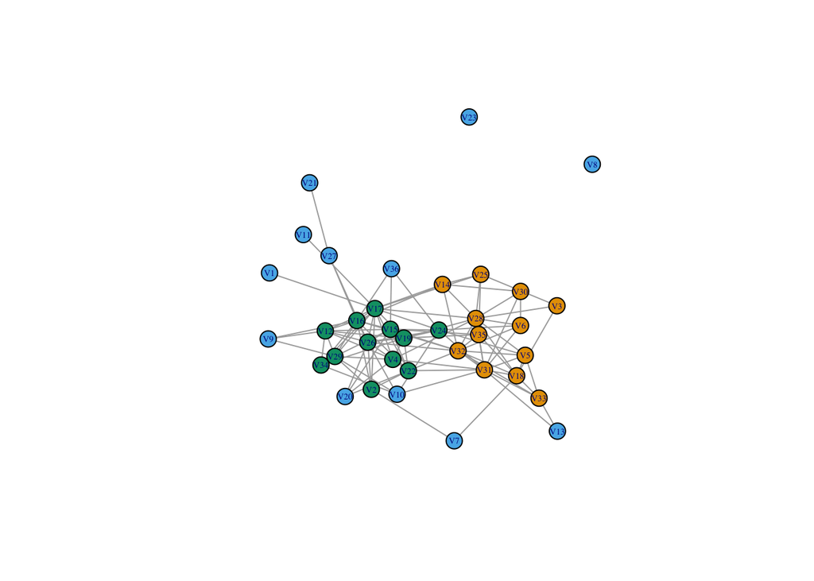

```r
best_fit_membership_probs <- lazega_out$memberships[[which.max(lazega_out$ICL)]]$Z
clust_assignments_1 <- apply(best_fit_membership_probs, 1, which.max)
set.seed(42)
plot(lazega, vertex.color = clust_assignments_1, vertex.size = 10, vertex.label.cex= 0.45)
```

```r
mhat = lazega_out$model_parameters[[which.max(lazega_out$ICL)]]$m
betahat = lazega_out$model_parameters[[which.max(lazega_out$ICL)]]$beta
theta = rbind(cbind(mhat + as.numeric(betahat), mhat))
hat_P_covar = exp(theta)/(1+exp(theta))
hat_P_covar
```

```
##            [,1]       [,2]      [,3]       [,4]       [,5]       [,6]
## [1,] 0.58958638 0.03702005 0.1721459 0.38700713 0.01661428 0.08373408
## [2,] 0.03702005 0.02276418 0.1982729 0.01661428 0.01013368 0.09803158
## [3,] 0.17214587 0.19827290 0.6983449 0.08373407 0.09803158 0.50431558
```

• What do the results of the two models have in common, and in what ways do they diﬀer?

```r
cbind(V(lazega)$name, clust_assignments, clust_assignments_1)
```

```
##             clust_assignments clust_assignments_1
##  [1,] "V1"  "2"               "2"
##  [2,] "V2"  "3"               "3"
##  [3,] "V3"  "1"               "1"
##  [4,] "V4"  "3"               "3"
##  [5,] "V5"  "1"               "1"
##  [6,] "V6"  "1"               "1"
##  [7,] "V7"  "2"               "2"
##  [8,] "V8"  "2"               "2"
##  [9,] "V9"  "2"               "2"
## [10,] "V10" "2"               "2"
## [11,] "V11" "2"               "2"
## [12,] "V12" "3"               "3"
## [13,] "V13" "1"               "2"
## [14,] "V14" "1"               "1"
```

[output cut: 22 more lines]